# Project 1 - DATS 6101

9/29/2019

### Chapter 1: Introduction

### Chapter 2: Description of Data

#### 2.1 Source Data

#### 2.2 Clean Data

- For our project, we will remove all movies that are television or DvDs versions and focus on movies published at theatre/ cinema.
- Change all movies with budget = 0 to NA.

```
## 'data.frame':    6507 obs. of  15 variables:
##  $ budget  : num  8000000 6000000 15000000 18500000 9000000 6000000 25000000 6000000 9000000 15000000 ...
##  $ company : Factor w/ 2179 levels "\"DIA\" Productions GmbH & Co. KG",..: 665 1683 1683 2068 2124 1159 1161 763 1683 1936 ...
##  $ country : Factor w/ 57 levels "Argentina","Aruba",..: 56 56 56 56 56 54 54 56 56 56 ...
##  $ director: Factor w/ 2759 levels "\xc1lex de la Iglesia",..: 2200 1305 2652 1074 2131 1955 1215 594 1011 563 ...
##  $ genre   : Factor w/ 17 levels "Action","Adventure",..: 2 5 1 1 2 7 2 7 5 7 ...
##  $ gross   : num  5.23e+07 7.01e+07 1.80e+08 8.52e+07 1.86e+07 ...
##  $ name    : Factor w/ 6731 levels "'71","'night, Mother",..: 4671 1829 6211 299 1880 3911 2892 784 3969 5313 ...
##  $ rating  : Factor w/ 5 levels "G","NC-17","PG",..: 5 4 3 5 3 5 3 5 4 5 ...
##  $ released: Factor w/ 2403 levels "1986-01-10","1986-01-17",..: 40 28 24 34 37 76 31 52 10 39 ...
##  $ runtime : int  89 103 110 137 90 120 101 120 96 96 ...
##  $ score   : num  8.1 7.8 6.9 8.4 6.9 8.1 7.4 7.8 6.8 7.5 ...
##  $ star    : Factor w/ 2504 levels "'Weird Al' Yankovic",..: 2458 1609 2350 2197 1146 374 531 928 1734 1045 ...
##  $ votes   : int  299174 264740 236909 540152 36636 317585 102879 146768 60565 129698 ...
##  $ writer  : Factor w/ 4199 levels "'Weird Al' Yankovic",..: 3728 1981 1862 1639 2559 2996 984 904 1981 1343 ...
##  $ year    : int  1986 1986 1986 1986 1986 1986 1986 1986 1986 1986 ...
```

### Chapter 3: Movie categories

#### 3.1 SMART Question

##### Does the genre has any effects on the classification of audiences and which genre achieve highest voting averages in three time intervals: 1986-1999, 2000-2010, and 2010-2016?

#### 3.2 Number of published movies by genre:

```
##
##    Action Adventure Animation Biography    Comedy     Crime     Drama
##      1309       385       272       341      2002       486      1311
##    Family   Fantasy    Horror   Musical   Mystery   Romance    Sci-Fi
##        14        31       268         2        37        14        13
##  Thriller       War   Western
##        18         2         2
```

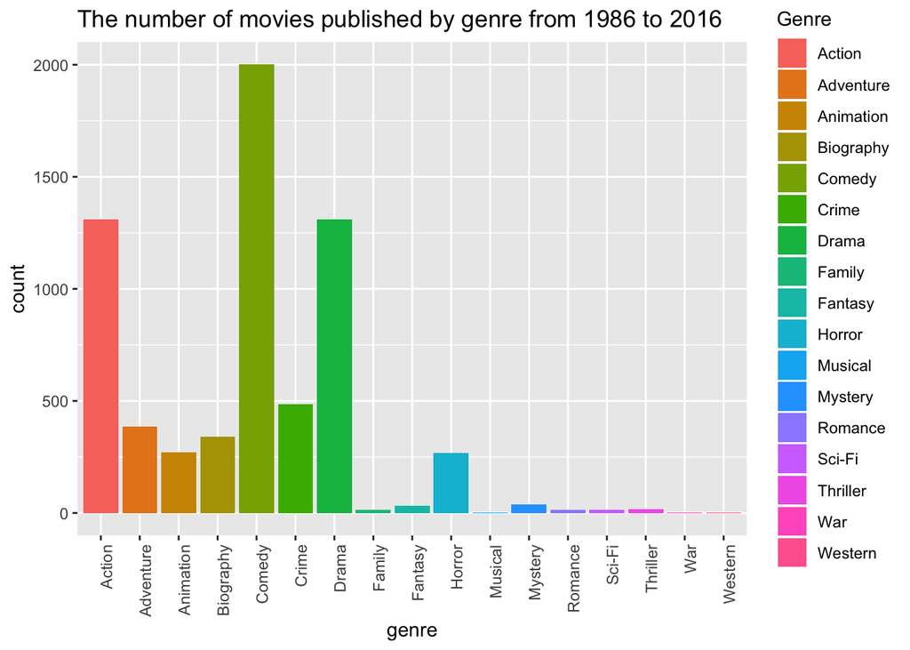

#### 3.3 Test dependence of genre and rating:

Movie ratings explanation:

- G – General Audiences: All ages admitted. Nothing that would offend parents for viewing by children.
- PG – Parental Guidance Suggested: Some material may not be suitable for children. Parents urged to give “parental guidance”. May contain some material parents might not like for their young children.
- PG-13 – Parents Strongly Cautioned: Some material may be inappropriate for children under 13. Parents are urged to be cautious. Some material may be inappropriate for pre-teenagers.
- R – Restricted: Under 17 requires accompanying parent or adult guardian. Contains some adult material. Parents are urged to learn more about the film before taking their young children with them.
- NC-17 – Adults Only: No One 17 and Under Admitted. Clearly adult. Children are not admitted.
- Create Contigency Table:

```
##
##         Action Adventure Animation Biography Comedy Crime Drama Horror
##   G          1        21        89         1     18     0    10      0
##   NC-17      0         0         0         1      5     4    12      0
##   PG       112       159       152        40    350     2   116      1
##   PG-13    517       107        18       109    706    46   410     51
##   R        679        98        13       190    923   434   763    216
```

- Chi-squared Test:

```
##
##  Pearson's Chi-squared test
##
## data:  contable2
## X-squared = 2503.9, df = 28, p-value < 2.2e-16
```

```
## X-squared
##  2503.949
```

```
## df
## 28
```

```
##
##             Action  Adventure   Animation  Biography      Comedy     Crime
##   G      28.751177   8.456228   5.9742705   7.489802   43.972388  10.67462
##   NC-17   4.518042   1.328836   0.9388139   1.176969    6.909947   1.67744
##   PG    191.400690  56.294321  39.7715720  49.860684  292.730468  71.06244
##   PG-13 403.337935 118.628805  83.8104801 105.071227  616.869783 149.74961
##   R     680.992156 200.291810 141.5048635 177.401318 1041.517414 252.83590
##
##              Drama      Horror
##   G      28.795105   5.8864136
##   NC-17   4.524945   0.9250078
##   PG    191.693128  39.1866960
##   PG-13 403.954189  82.5779730
##   R     682.032633 139.4239096
```

```
## [1] 0
```

- Null Hypothesis: The movie genre and its rating are independent.
- The p-value in the chi-squared test is 0 is close to 0, much smaller than significance level (0.05). Therefore, we reject the null.
- Conclusion: The movie genre and rating are NOT independent.

#### 3.4 Genres with most votes

- To have a better observation, we will divide our reseacrh period into three time intervals: 1986-1999, 2000-2009, 2010-2016
- Then, we save our movies data into three datasets.

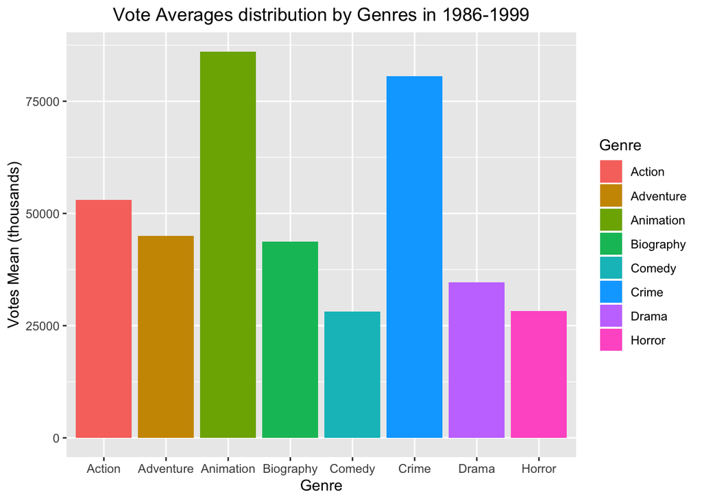

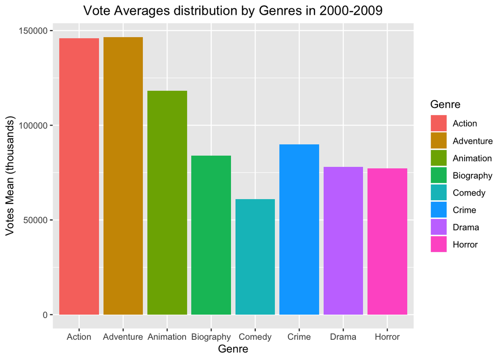

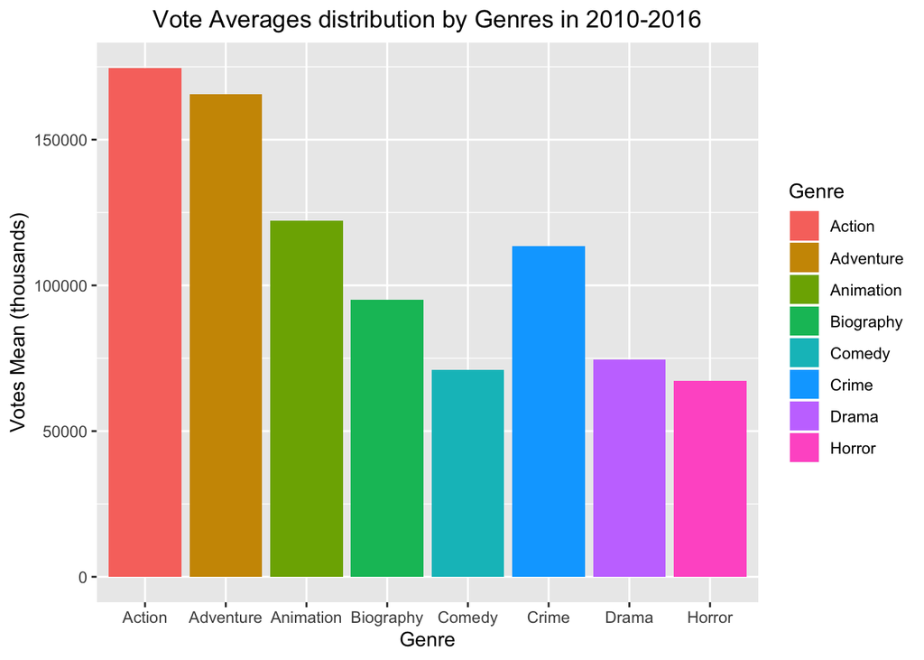

### Chapter 4: Movie Scores

#### 4.1 SMART Question

##### Is there any relationships between the votes and the scores and are the score means the same across all genres and all ratings?

#### 4.2 Scores and Votings Relationship

- We divide votes and scores into different categories:

Votes:

Scores:

- Good score: from 7.5
- Medium score: from 5.0 to below 7.5
- Bad score: below 5.0

Now, we plot the distribution of votings across the scores using boxplots and mapping plots"

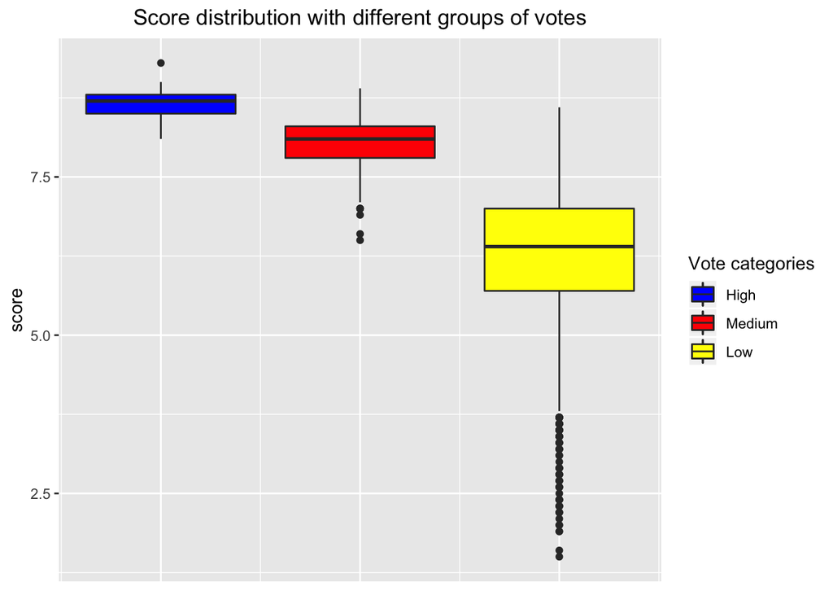

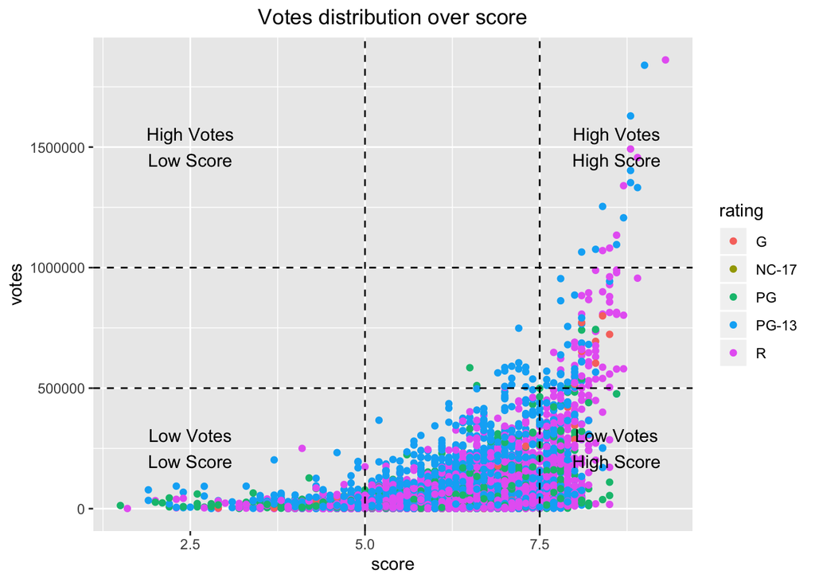

- As shown in boxplots, the movies with highest votes (above 1 million votes) tend to have high scores and the movies with low scores (below 5) tend to get bad votes. However, high score movies do not certainly have high votes and low votes movies do not mean that they have low score.
- The mapping plot also gives us the same observation, every movies with votes over 1 million always possesses a high score. And at around 500000 votes and below, the score varies extensively. Movies with scores below 5.0 have low votes.
- This illustrates that people often highly grade their favorite movies (with high votes). Meanwhile, they do not recommend bad movies (low score). The reason for the large variety of scores at medium votes ( below 500000) may be due to the genre of the movies that affect the number of audiences. Many genres have good quality of movies but they are not of interest to audiences such as Biography, War, Scifi, Drama, which makes them get low votes even they are highly graded.

#### 4.3 Score means of different genres and different ratings

##### By genres:

- Anova test score means by famous genres: (we will not include genres with low sample sizes < 50)

```
##               Df Sum Sq Mean Sq F value Pr(>F)
## genre          7    703  100.41   112.6 <2e-16 ***
## Residuals   6366   5675    0.89
## ---
## Signif. codes:  0 '***' 0.001 '**' 0.01 '*' 0.05 '.' 0.1 ' ' 1
```

- Null Hypothesis: The score means of all genres are the same.
- The p-value of the test is 2.62582310^{-156}, which is very close to 0 and much smaller than significance level (0.05).
- Therefore, we reject the null and conclude that the scores means of different genres are not all the same.

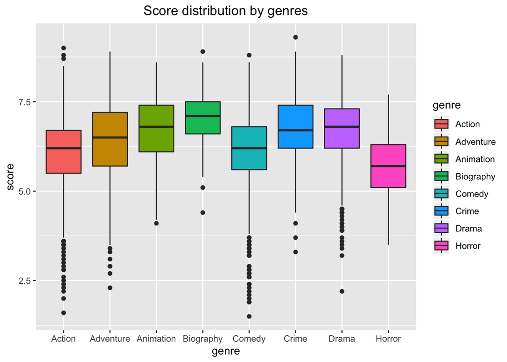

- As shown in the boxplots, the following pairs have pretty the same tail boxplots and overlapped interquartile ranges: Action-Comedy, Animation-Crime, Animation-Drama and Crime-Drama.
- This illustrates that these pairs seem to be NOT significant in their mean values. We will confirm with a Tukey test.
- We will conduct an ad hoc procedure to see which pairs are significant.

```
##   Tukey multiple comparisons of means
##     95% family-wise confidence level
##
## Fit: aov(formula = score ~ genre, data = movies_fam)
##
## $genre
##                            diff         lwr         upr     p adj
## Adventure-Action     0.24935065  0.08339100  0.41531030 0.0001439
## Animation-Action     0.64124809  0.45050112  0.83199506 0.0000000
## Biography-Action     0.94298282  0.76894608  1.11701957 0.0000000
## Comedy-Action        0.04740260 -0.05434490  0.14915009 0.8518201
## Crime-Action         0.62322431  0.47117296  0.77527565 0.0000000
## Drama-Action         0.59413851  0.48229122  0.70598580 0.0000000
## Horror-Action       -0.39444660 -0.58636854 -0.20252466 0.0000000
## Animation-Adventure  0.39189744  0.16516489  0.61862999 0.0000046
## Biography-Adventure  0.69363217  0.48076595  0.90649840 0.0000000
## Comedy-Adventure    -0.20194805 -0.36124586 -0.04265024 0.0030798
## Crime-Adventure      0.37387366  0.17857171  0.56917561 0.0000002
## Drama-Adventure      0.34478786  0.17885698  0.51071874 0.0000000
## Horror-Adventure    -0.64379725 -0.87151916 -0.41607533 0.0000000
## Biography-Animation  0.30173473  0.06902498  0.53444449 0.0021768
## Comedy-Animation    -0.59384549 -0.77882548 -0.40886551 0.0000000
## Crime-Animation     -0.01802378 -0.23478322  0.19873565 0.9999968
## Drama-Animation     -0.04710958 -0.23783152  0.14361236 0.9954442
## Horror-Animation    -1.03569469 -1.28206651 -0.78932287 0.0000000
## Comedy-Biography    -0.89558023 -1.06327631 -0.72788414 0.0000000
## Crime-Biography     -0.31975852 -0.52196889 -0.11754814 0.0000456
## Drama-Biography     -0.34884432 -0.52285362 -0.17483501 0.0000000
## Horror-Biography    -1.33742942 -1.57110324 -1.10375560 0.0000000
## Crime-Comedy         0.57582171  0.43107090  0.72057252 0.0000000
## Drama-Comedy         0.54673591  0.44503535  0.64843647 0.0000000
## Horror-Comedy       -0.44184920 -0.62804054 -0.25565785 0.0000000
## Drama-Crime         -0.02908580 -0.18110574  0.12293414 0.9991065
## Horror-Crime        -1.01767090 -1.23546502 -0.79987679 0.0000000
## Horror-Drama        -0.98858511 -1.18048217 -0.79668805 0.0000000
```

- As we see from our Tukey test, there are no significant differences in score means of the following pairs: Action-Comedy, Animation-Crime, Animation-Drama, Crime-Drama.

##### By ratings:

```r
anova_sr <- aov(score ~ rating, movies_fam )
summary(anova_sr)
```

```
##               Df Sum Sq Mean Sq F value Pr(>F)
## rating         4    100  25.059   25.43 <2e-16 ***
## Residuals   6369   6277   0.986
## ---
## Signif. codes:  0 '***' 0.001 '**' 0.01 '*' 0.05 '.' 0.1 ' ' 1
```

- Null Hypothesis: The score means of all ratings are the same.
- The p-value of the test is 6.286582310^{-21}, which is very close to 0 and much smaller than significance level (0.05).
- Therefore, we reject the null and conclude that the scores means of different ratings are not all the same.

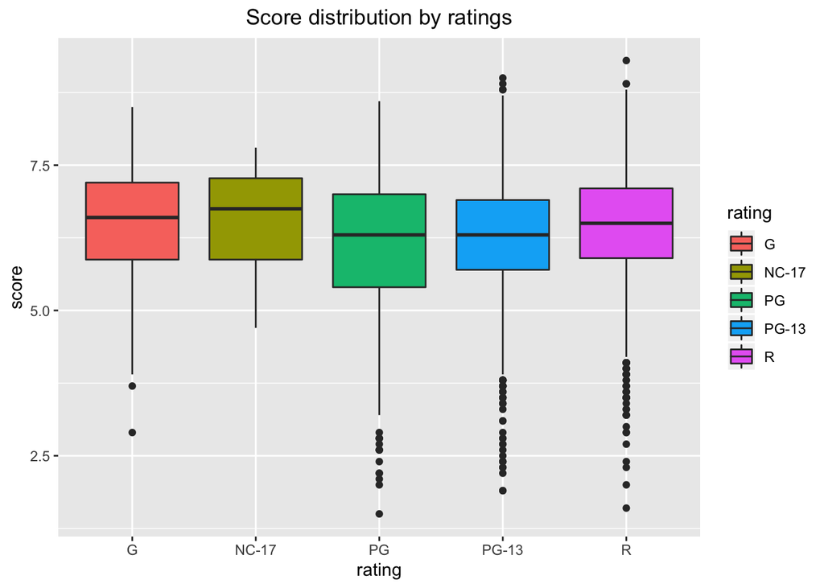

```
##   Tukey multiple comparisons of means
##     95% family-wise confidence level
##
## Fit: aov(formula = score ~ rating, data = movies_fam)
##
## $rating
##                     diff           lwr         upr     p adj
## NC-17-G      0.093831169 -0.5274131104  0.71507545 0.9939582
## PG-G        -0.313182097 -0.5587127235 -0.06765147 0.0045868
## PG-13-G     -0.204858889 -0.4418152441  0.03209747 0.1268800
## R-G          0.001891263 -0.2318287175  0.23561124 0.9999999
## PG-NC-17    -0.407013266 -0.9913122674  0.17728574 0.3169737
## PG-13-NC-17 -0.298690057 -0.8794381518  0.28205804 0.6255147
## R-NC-17     -0.091939906 -0.6713750307  0.48749522 0.9927004
## PG-13-PG     0.108323208  0.0005772882  0.21606913 0.0480280
## R-PG         0.315073360  0.2146447873  0.41550193 0.0000000
## R-PG-13      0.206750152  0.1296208833  0.28387942 0.0000000
```

- As we see from our Tukey test, there are significant differences in score means of the following pairs: PG-13 & R, PG & R, PG & PG-13, G & PG.
- The other pairs are not significnace at 0.05 level.

### Chapter 5: Profit and Return on Investment

#### 5.3 Profit and Votes Relationship

#### 5.4 Profit and Scores Relationship

### Chapter 6:

For chapter 6, we can use countries to analyze but it will be very long. So we can have another option is to use ROI as our chapter 6.

### Chapter 7: Conclusion